# Practical Machine Learning

Ravikiran Kolanpaka

2017-04-21

## DATA

Download the train and test data from the mentioned sites. Upload the files to R. Read the data files by interpretting the empty fields and other fields as NA.

```r
setwd("/home/ravikiran/coursera")
pmltraining <- read.csv("pml-training.csv",na.strings = c("NA", "#DIV/0!", ""))
pmltesting <- read.csv("pml-testing.csv",na.strings = c("NA", "#DIV/0!", ""))
```

```r
table(pmltraining$classe)
```

```
##
##    A    B    C    D    E
## 5580 3797 3422 3216 3607
```

If you look at the data the first 6 variables just provide inferences about the data. Hence, They can be removed.

```r
pmltraining <- pmltraining[,7:160]
pmltesting <- pmltesting[,7:160]
```

After inputting the data, the variable gyros_forearm_x has been converted to factor variable, when infact it is numeric. Hence, The variable is converted into numeric variable.

```r
pmltraining$gyros_forearm_x <- as.numeric(pmltraining$gyros_forearm_x)
pmltesting$gyros_forearm_x <- as.numeric(pmltesting$gyros_forearm_x)
```

After looking at the data, Most of the columns have NAs. Hence, Removing them using

```r
pmltraining <- pmltraining[ lapply( pmltraining, function(x) sum(is.na(x)) / length(x) ) < 0.4 ]
pmltesting <- pmltesting[ lapply( pmltesting, function(x) sum(is.na(x)) / length(x) ) < 0.4 ]
```

Splitting the training data internally by using the classe column into train and test data by using caret package. Subsample 60% of the set into training purposes. Rest 40% of the data can be used as test data.

```r
library(caret)
set.seed(1234)
inTrain <- createDataPartition(y = pmltraining$classe, p = 0.60,list = FALSE)
train_data <- pmltraining[inTrain,]
test_data <- pmltraining[-inTrain,]
```

# Feature Selection

As the number of Features are 53 , They can be reduced by checking the relative importance of the variables using Random Forest varImp method.

```r
library(randomForest)
```

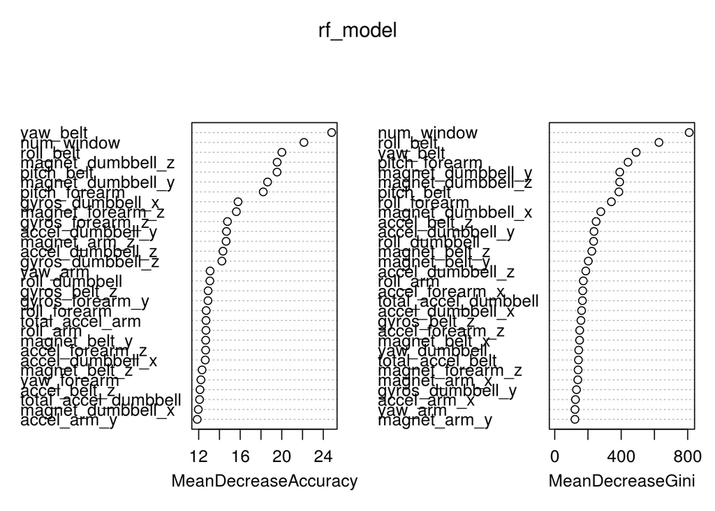

```r
set.seed(1234)
rf_model <- randomForest(classe~., data=train_data, importance=TRUE, ntree=100)
varImpPlot(rf_model)
```

By checking the above Accuracy and Gini index graphs. We select the top 10 features required to build the model.

The 10 Features are: yaw_belt, roll_belt, num_window, pitch_belt, magnet_dumbbell_y, magnet_dumbbell_z, pitch_forearm, accel_dumbbell_y, roll_arm, and roll_forearm.

These Features will be used to build the model.

```r
set.seed(3141592)
fitModel <- train(classe~roll_belt+yaw_belt+num_window+pitch_belt+magnet_dumbbell_y+magnet_dumbbell_z+pitch_forearm+accel_dumbbell_y+roll_arm+roll_forearm,
                  data=train_data,
                  method="rf",
                  trControl=trainControl(method="cv",number=2),
                  prox=TRUE,
                  verbose=TRUE,
                  allowParallel=TRUE)
```

Prediction on the test data.

```r
predictions <- predict(fitModel, newdata=test_data)
confusionMat <- confusionMatrix(predictions, test_data$classe)
confusionMat
```

```
## Confusion Matrix and Statistics
##
##           Reference
## Prediction    A    B    C    D    E
##          A 2232    2    0    0    0
##          B    0 1512    1    0    0
##          C    0    4 1367    2    0
##          D    0    0    0 1284    2
##          E    0    0    0    0 1440
##
## Overall Statistics
##
##                Accuracy : 0.9986
##                  95% CI : (0.9975, 0.9993)
##     No Information Rate : 0.2845
##     P-Value [Acc > NIR] : < 2.2e-16
##
##                   Kappa : 0.9982
##  Mcnemar's Test P-Value : NA
##
## Statistics by Class:
##
##                      Class: A Class: B Class: C Class: D Class: E
## Sensitivity            1.0000   0.9960   0.9993   0.9984   0.9986
## Specificity            0.9996   0.9998   0.9991   0.9997   1.0000
## Pos Pred Value         0.9991   0.9993   0.9956   0.9984   1.0000
## Neg Pred Value         1.0000   0.9991   0.9998   0.9997   0.9997
## Prevalence             0.2845   0.1935   0.1744   0.1639   0.1838
## Detection Rate         0.2845   0.1927   0.1742   0.1637   0.1835
## Detection Prevalence   0.2847   0.1928   0.1750   0.1639   0.1835
## Balanced Accuracy      0.9998   0.9979   0.9992   0.9991   0.9993
```

# Estimation of out-of sample error rate.

As the test data was removed and is not been used for training the model, it can be used to estime the out of sample error rate. The Random forest out of sample error rate can be calculated by using the following code.

```r
missClassification_error_rate = function(values, predicted) {
  sum(predicted != values) / length(values)
}
OOS_errRate = missClassification_error_rate(test_data$classe, predictions)
OOS_errRate
```

```
## [1] 0.001401988
```

Prediction on the 20 test cases given by coursera.

```r
predictions <- predict(fitModel, newdata=pmltesting)
pmltesting$classe <- predictions
```

```r
submit <- data.frame(problem_id = pmltesting$problem_id, classe = predictions)
write.csv(submit, file = "coursera-submission.csv", row.names = FALSE)
```